# Analysis of different classification model

INFO 526 - Fall 2024 - Project 02

Author

Affiliation

Visual Voyagers

College of Information, University of Arizona

## ##Introduction

This project uses the Wisconsin Breast Cancer dataset to train and evaluate Logistic Regression, SVM, and Naive Bayes models, comparing their performance with metrics like accuracy, precision, recall, and AUC.It highlights the role of identifying the most effective model for diagnosis of how machine learning can enable, accurate decision-making in healthcare.

## ##Background

The **Breast Cancer Wisconsin Diagnostic Dataset** is a widely used, high-quality dataset containing **569 samples** with **30 features** that describe tumor characteristics, allowing for effective **benign vs. malignant** binary classification.

## ##Dataset

Source: The data set we choose for this project is “Breast Cancer Diagnostic Data” we are getting the data set from UCI Machine Learning Repository: https://archive.ics.uci.edu/ml/datasets/Breast+Cancer+Wisconsin+%28Diagnostic%29

The source of dataset https://www.kaggle.com/datasets/uciml/breast-cancer-wisconsin-data

## ##Exploration

### ###Question 1: How does the accuracy of a mdoel compare to another when predicting the diagnosis? Which model performs best on the test set?

#### ####Introduction

This question focuses on comparing the accuracy scores of Logistic Regression, Naive Bayes, and SVM models across training, validation, and test datasets.

#### ####Question 2: How do the Receiver Operating Characteristic (ROC) curves and Area Under the Curve (AUC) scores differ among the models?

#### ####Introduction

The ROC curves and AUC scores provide a comparative analysis of the models’ performance in distinguishing between classes. They highlight differences in sensitivity and specificity, offering insights into which model performs best in handling classification tasks.

#### ####Approach

-By comparing the ROC curves and AUC scores, we aim to identify the model with the best overall performance, particularly in handling imbalanced data and balancing sensitivity and specificity effectively.

#### ####Question 3:How do the top two correlated features with the target variable influence the classifications of SVM, Logistic Regression, and Naive Bayes?

#### ####Introduction

It shows how top two features are highly correlated with the target variable, significantly impact model classification.

#### ####Analysis

##### #####fig.5

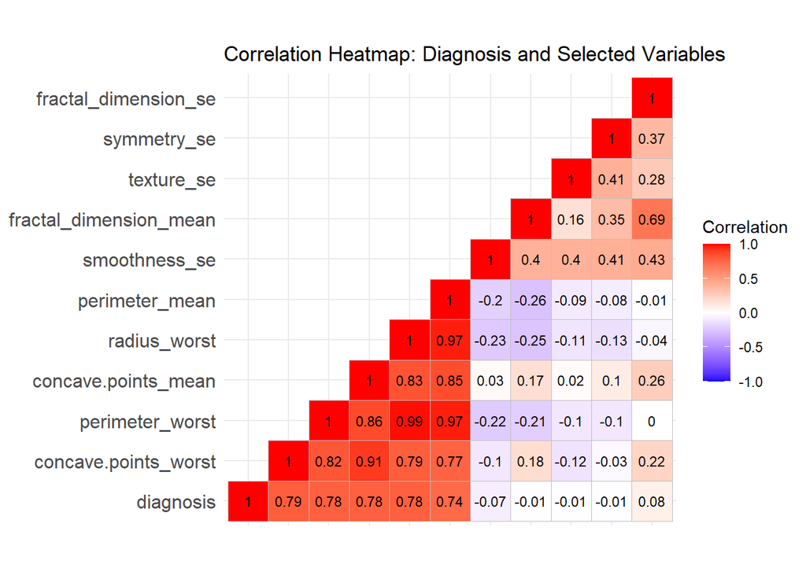

!Heatmap of Correlation matrix

The heatmap highlights the correlation between “diagnosis” and other variables. Strong positive correlations, such as **radius_worst** and **concave.points_mean**, emphasize their significance in predicting the diagnosis. Notably, no strong negative correlations are observed, indicating that most influential variables are positively associated with the target.

Multinomial Naive Bayes assumes that all features are conditionally independent—a condition rarely met in practice. This unrealistic assumption leads to its subpar performance compared to the other algorithms.

While, Logistic Regression assumes a linear relationship between the target variable and the independent variables, which aligns well with our dataset, resulting in its superior performance.

Concluding,the difference is subtle because we are dealing with a very small percentage of error margin. However, even a small difference in a Machine Learning algorithm’s accuracy can have far-reaching impacts in the real world.

## ##Discussion and Conclusion

Logistic Regression performed the best as it assumes linear separability between the target and features, which aligns well with the dataset’s characteristics. while Naive Bayes performed the worst due to its assumption of feature independence, which was violated as many predictors were highly correlated. SVM is highly sensitive to hyper-parameter if the data is linearly separable might not offer significant advantages over logistic regression. Hence, model selection is very important.

## ##Future work

• Optimize the parameters of each model through hyperparameter tuning and analyze the resulting improvements.

• Investigate additional models like Decision Trees, KNNs, and compare their performance with the current ones.

• Study and visualize alternative model evaluation metrics for deeper insights.

## ##References

- Dataset Source:

UCI Machine Learning Repository: Breast Cancer Wisconsin (Diagnostic) Dataset. [Link](https://archive.ics.uci.edu/ml/datasets/Breast+Cancer+Wisconsin+%28Diagnostic%29)

- Machine Learning Algorithms:

Hastie, T., Tibshirani, R., & Friedman, J. (2009). The Elements of Statistical Learning: Data Mining, Inference, and Prediction. Springer.

Murphy, K. P. (2012). Machine Learning: A Probabilistic Perspective. MIT Press.

- R Libraries Used:

Chang, W., et al. (2023). plotly: Create Interactive Web Graphics via ‘plotly.js’. R package version 4.10.1.

R Core Team (2023). R: A Language and Environment for Statistical Computing. R Foundation for Statistical Computing, Vienna, Austria

- Correlation Analysis:

Schober, P., Boer, C., & Schwarte, L. A. (2018). Correlation Coefficients: Appropriate Use and Interpretation. Anesthesia & Analgesia, 126(5), 1763–1768.